# Geodesics_questions_and_answers

## Question 7

Now we'll put together the funtion we computed in qustion 6 to render an image of the surface of a black hole as viewed at some distance. To give us some reference we're going to texture the surface of the event horizon with an image of the earth surface, this is terrible unphysical since the earth is not a black hole, it's not emissive, etc etc but it's more interesting that just plotting lines of constant $\phi$ and $\theta$.

We'll take the image below as our convention for how to put coordinates on a sphere though I'll be using radians instead of degrees in the code.

[figure not shown]

This code is not that interesting to write so I'll just give it to you, we load in an image (which you need to download from [here](https://upload.wikimedia.org/wikipedia/commons/thumb/2/23/Blue_Marble_2002.png/2560px-Blue_Marble_2002.png)) and then use an interpolater to get a function that maps lat,lon points to colors `earth([(lat0,lon0), (lat1,lon1)...]) -> [(r0, g0, b0), (r1, g1, b1)...]`

```
(1280, 2560, 3)
```

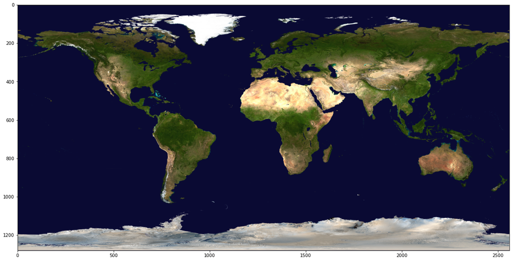

```python
from matplotlib import image
import scipy.interpolate
#get this from https://upload.wikimedia.org/wikipedia/commons/thumb/2/23/Blue_Marble_2002.png/2560px-Blue_Marble_2002.png
im = image.imread("./Blue_Marble_2002.png")
print(im.shape)


lat = np.linspace(-pi/2, pi/2, im.shape[0])
lon = np.linspace(-pi, pi, im.shape[1])

latv, lonv = np.meshgrid(lat, lon, sparse=False, indexing='ij')

earth_interp = scipy.interpolate.RegularGridInterpolator([lat, lon], im, bounds_error=False)

def to_points(xv, yv): return np.array([xv, yv]).transpose((1,2,0))
def wrap_lon(phase): return (phase + pi) % (2 * pi) - pi #wraps to the interval -pi, pi
def wrap_lat(phase): return (phase + pi/2) % (pi) - pi / 2 #wraps to the interval -pi/2, pi/2

def earth(lat, lon):
    points = to_points(wrap_lat(lat), wrap_lon(lon))
    return np.clip(earth_interp(points), 0.0, 1.0)

fig, axes = plt.subplots(figsize = (20,20))
plt.imshow(earth(latv, lonv))
```

I'm going to walk you through this a little bit because the process of rendering this image is a little fidly and look me a while to get right.

First we want to define the bounds of our image, for want of better names I'll call the coordinates x and y but really they measure the angles of rays hitting our observers eye. We'll choose $2\pi/3$ as the persons maximum field of view.

```python
fov = 2*pi/3 #field of vieew

#define coordinates for our image window
x = np.linspace(-fov/2, fov/2, 500)
y = np.linspace(-fov/2, fov/2, 500)
```

Next we define a 'mesh' this means that while x and y are just arrays [x0, x1 ...] , xv and yv have two dimensions such that `(xv[i,j], yv[i,j])` is the coordinate of the (i,j) grid point. This allows us to do fast numpy things like `r = np.sqrt(xv**2 + yv**2)` which gives us a variable defined over the image plane equal to the distance from the origin.

```python
xv, yv = np.meshgrid(x, y, sparse=False, indexing='ij')
```

Next we define r and $\phi$ in the image plane. If you look at the diagram from question 6 you should be able to convinve yourself that it makes sense to define $\alpha = r$ and $\beta = \phi$

```python
r = np.sqrt(xv**2 + yv**2) #ranges from 0 to pi/3
phi = np.arctan2(xv, yv) #ranges from -pi to pi
#we map alpha as define above onto r and beta onto phi
alpha = r
beta = phi
```

Now we actually map alpha onto gamma, here `spacetime` is a function you need to write that maps alpha onto gamma according to the spacetime you're in. You want to interpolate the data you got from question 6. The `pi/2 - spacetime(alpha)`is because we're measuring our azimuthal angles from the equator rather than from the poles.

```python
def spacetime(x): return x #a dummy function that you need to fill in
gamma = pi/2 - spacetime(alpha)
beta = beta
```

And finally, just so that we can view the earth from the side rather than only at one of the poles, we'll map to 3D cartesian coordinates, rotate the axes and then map back. Now$(\phi, \theta)$ are the longitude and lattitude on the earth so we can map straight to an image pixel and we're done!

```python
def polar_to_cart(r, phi, theta):
    """
    Convert a spherical polar coordinate system
    (r, phi theta) 0 < r, -pi < phi < pi, -pi/2 < theta < pi/2
    into Cartesian x,y,z coordinates

    NB:
    Phi measures rotations about the z axis
    Theta is the angle above or below the xy plane
    This is slightly different from the typical definition where theta is the angle with the z axis.
    """
    return r * np.cos(phi) * np.cos(theta), r * np.sin(phi)*np.cos(theta), r * np.sin(theta)

def cart_to_polar(x,y,z):
    """
    Reverse the above transformation.
    Uses the convention that phi ranges from -pi to pi
    and theta ranges from -pi/2 to pi
    """
    r = np.sqrt(x**2 + y**2 + z**2)
    theta = np.arcsin(z / r)
    phi = np.arctan2(y,x)
    return r, phi, theta

x,y,z = polar_to_cart(r = 1, phi = beta, theta = gamma)
_, phi, theta = cart_to_polar(x,-z,y)
```

Can you put all that together to make an image of the surface of the earth if the surface of the earth also happend to be the event horizon of a black hole? (Terms and conditions apply, this can't actually happen, gravitational redshift is ignored etc etc)

I wouldn't blame you for skipping to the solution on this one, it's a bit tricky but the payoff is nice.

## Answer 7

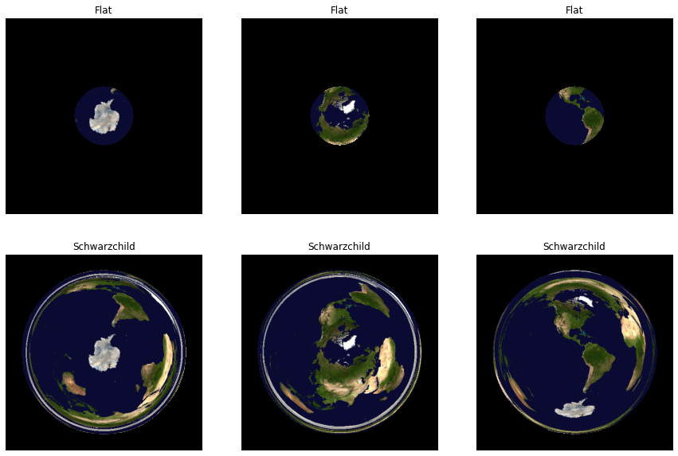

```python
r_obs = 3
interp_alphas = np.linspace(0.001,pi/2, 1000) # the range of alpha that we will use
schwarzchild_alphas, schwarzchild_gammas = compute_interpolation(interp_alphas, r_obs, r_s = 1)
flat_alphas, flat_gammas = compute_interpolation(interp_alphas, r_obs, r_s = 0)

#these two functions interpolate the gamma(alpha) functions we calculated earlier
#right = np.NaN tells them to return NaN if alpha is too large and the ray doesn't hit.
def schwarzchild_gamma(alpha):
    shape = alpha.shape
    return np.interp(alpha.flatten(), schwarzchild_alphas, schwarzchild_gammas, right = np.NaN).reshape(shape)

def flat_gamma(alpha):
    shape = alpha.shape
    return np.interp(alpha.flatten(), flat_alphas, flat_gammas, right = np.NaN).reshape(shape)

fig, rows = plt.subplots(nrows = 2, ncols = 3, figsize = (15,10))

for axes, name, spacetime in zip(rows, ["Flat", "Schwarzchild"],[flat_gamma, schwarzchild_gamma]):
    fov = 2*pi/3 #field of vieew

    #define coordinates for our image window
    x = np.linspace(-fov/2, fov/2, 500)
    y = np.linspace(-fov/2, fov/2, 500)

    #make them into grids
    xv, yv = np.meshgrid(x, y, sparse=False, indexing='ij')

    #define r and phi for our image window
    r = np.sqrt(xv**2 + yv**2) #ranges from 0 to pi/3
    phi = np.arctan2(xv, yv) #ranges from -pi to pi

    #we map alpha as define above onto r and beta onto phi
    alpha = r
    beta = phi

    gamma = pi/2 - spacetime(alpha)
    beta = beta


    x,y,z = polar_to_cart(r = 1, phi = beta, theta = gamma)
    _, phi, theta = cart_to_polar(x,-z,y)

    axes[0].imshow(earth(gamma, beta))
    axes[1].imshow(earth(-gamma, beta))
    axes[2].imshow(earth(theta, phi))

    for a in axes:
        a.axis('off')
        a.set(title = name)
```